# 🛒 NLP & Inteligência de Experiência do Cliente no E-Commerce Brasileiro (Olist)

**Autor:** Dr. Silvio da Rosa Paula • Portfólio de Ciência de Dados, NLP & Machine Learning  
**Dataset Oficial:** Olist Brazilian E-Commerce (`98,673` pedidos avaliados únicos | `42,173` avaliações escritas em PT-BR | `2016-09-04` a `2018-10-17`)

## 🎯 Problema de Negócio & Pergunta Central

Grandes marketplaces brasileiros processam dezenas de milhares de avaliações de clientes em português informal (com abreviações, erros de digitação, negações compostas e reclamações mistas). O desafio operacional do time de **Experiência do Cliente (CX) e Logística** é responder a três perguntas críticas:

1. **Predição & Triagem Prioritária (SAC):** Conseguimos classificar automaticamente a polaridade real do cliente (`Negativo 1–2★`, `Neutro 3★`, `Positivo 4–5★`) e estimar a probabilidade calibrada de **Detrator (`1–2★`)** combinando **NLP em português + sinais logísticos do pedido**?
2. **Causa-Raiz Acionável:** Quais falhas operacionais (*Atraso na Entrega*, *Defeito/Avaria*, *Item Errado*, *Pedido Incompleto*) dominam as reclamações em cada categoria de produto?
3. **Atendimento Assistido (RAG Zero Alucinação):** Como recuperar casos históricos resolvidos e montar rascunhos de resposta personalizados em **milissegundos** sem custo de GPU?

### Principais Rigores Metodológicos Adotados

- **Targets Reais (Sem Vazamento Circular):** Prevemos a **nota real atribuída pelo cliente** (`review_score`), em vez de usar rótulos ruidosos de léxicos automáticos como alvo.
- **Zero Duplicação `m:m` (Group Leakage):** Agregação prévia de `order_items` no grão `order_id` antes do join com `reviews`.
- **Split Cronológico Estrito:** Treino (`70%`) → Validação (`15%`) → Teste *Out-of-Time* (`15%`), com todos os vetorizadores TF-IDF, imputadores, escalonadores e *encoders* ajustados **exclusivamente no Treino**.
- **Preservação de Negações em PT-BR:** Ao contrário de listas padrão de *stopwords* que apagam `"não"`, `"nem"`, `"nunca"` e `"sem"`, formamos bigramas de negação (`nao_recebi`, `nao_recomendo`) combinados com n-gramas de caracteres (`char_wb 3–5`).

## 1. Ingestão, Esquema e Auditoria de Qualidade dos Dados

```python
import sys, json, time, warnings
from pathlib import Path

warnings.filterwarnings("ignore")
ROOT = Path(".").resolve()
sys.path.insert(0, str(ROOT / "src"))

import numpy as np
import pandas as pd
import matplotlib.pyplot as plt
import seaborn as sns
import networkx as nx
import lightgbm as lgb
import xgboost as xgb
from scipy import sparse
from IPython.display import Image, display
from sklearn.calibration import CalibratedClassifierCV, calibration_curve
from sklearn.decomposition import NMF, TruncatedSVD
from sklearn.dummy import DummyClassifier
from sklearn.feature_extraction.text import TfidfVectorizer
from sklearn.linear_model import LogisticRegression
from sklearn.metrics import brier_score_loss, confusion_matrix, f1_score, precision_recall_curve, roc_curve
from sklearn.model_selection import StratifiedKFold, cross_val_predict
from sklearn.naive_bayes import ComplementNB
from sklearn.svm import LinearSVC

from nlp_pipeline import (
    ASPECT_PATTERNS, CLASSES_ORDER, CustomerSupportRAG,
    bootstrap_ci, build_tabular_preprocessor, build_text_vectorizer,
    chronological_split, clean_pt_text, compute_lexicon_score,
    enrich_text_signals, evaluate_multiclass, evaluate_slices,
    lexicon_predict_labels,
)

sns.set_theme(style="whitegrid", context="notebook")
DATA_PATH = ROOT / "data" / "olist_reviews_nlp.parquet"
FIG_DIR = ROOT / "outputs" / "figures"

df_all = pd.read_parquet(DATA_PATH)
print(f"Total de pedidos avaliados únicos (1 linha por order_id): {len(df_all):,}")
print(f"Colunas disponíveis ({df_all.shape[1]}): {list(df_all.columns)}")
print(f"Período de compras: {df_all['order_purchase_timestamp'].min():%Y-%m-%d} a {df_all['order_purchase_timestamp'].max():%Y-%m-%d}")

null_report = pd.DataFrame({
    "Nulos": df_all.isna().sum(),
    "% Nulo": (df_all.isna().mean() * 100).round(2),
    "Tipo": df_all.dtypes.astype(str),
})
display(null_report[null_report["Nulos"] > 0])

# Mantemos todas as avaliações com texto escrito (título OU mensagem >= 3 chars)
df_txt = df_all[df_all["texto_completo"].fillna("").str.len() >= 3].copy().reset_index(drop=True)
df_txt = enrich_text_signals(df_txt)
print(f"\nAvaliações com texto escrito (>= 3 caracteres): {len(df_txt):,} ({len(df_txt)/len(df_all)*100:.1f}% do total)")
display(df_txt["sentimento_real"].value_counts().to_frame("Quantidade").assign(Percentual=lambda d: (d["Quantidade"]/len(df_txt)*100).round(1)))
```

```
Total de pedidos avaliados únicos (1 linha por order_id): 98,673
Colunas disponíveis (34): ['review_id', 'order_id', 'review_score', 'review_comment_title', 'review_comment_message', 'review_creation_date', 'review_answer_timestamp', 'customer_id', 'order_status', 'order_purchase_timestamp', 'tempo_entrega_dias', 'atraso_entrega_dias', 'prazo_estimado_dias', 'ent…
Período de compras: 2016-09-04 a 2018-10-17
```

|  | Nulos | % Nulo | Tipo |
| --- | --- | --- | --- |
| review_comment_title | 87121 | 88.29 | object |
| review_comment_message | 57897 | 58.68 | object |
| tempo_entrega_dias | 2843 | 2.88 | float64 |
| atraso_entrega_dias | 2843 | 2.88 | float64 |
| qtd_itens | 756 | 0.77 | float64 |
| qtd_vendedores | 756 | 0.77 | float64 |
| valor_itens | 756 | 0.77 | float64 |
| frete_total | 756 | 0.77 | float64 |
| peso_medio_g | 772 | 0.78 | float64 |
| fotos_produto | 2135 | 2.16 | float64 |
| categoria_principal | 756 | 0.77 | object |
| valor_total | 756 | 0.77 | float64 |
| razao_frete | 756 | 0.77 | float64 |

```
Avaliações com texto escrito (>= 3 caracteres): 42,173 (42.7% do total)
```

| sentimento_real | Quantidade | Percentual |
| --- | --- | --- |
| Positivo | 27655 | 65.6 |
| Negativo | 10921 | 25.9 |
| Neutro | 3597 | 8.5 |

### 🔎 Análise da Auditoria de Dados

1. **Eliminação de Duplicação Cartesiana (`m:m`):** A base consolidada contém exatamente **`98,673` pedidos avaliados únicos**, agregando itens e fretes no grão `order_id` antes do cruzamento com `reviews`. Isso elimina vazamento de grupo (mesmo comentário repetido em treino e teste).
2. **Decisão sobre Valores Ausentes (Preservar vs. Descartar):**
   - `review_comment_title` é nulo em **88,3%** dos pedidos e `review_comment_message` em **58,7%**. Em vez de exigir ambos preenchidos (o que descartaria ~88% dos dados), combinamos `título + mensagem` e mantemos todas as **`42,173` avaliações com texto escrito (`≥ 3 caracteres`)** — quase 4× mais dados úteis que abordagens restritivas.
   - `tempo_entrega_dias` e `atraso_entrega_dias` são nulos em **2,88%** dos registros exatamente porque o pedido **não foi entregue** (cancelado ou extraviado). Longe de ser ruído a ser descartado, esse *missing* é um fortíssimo preditor de Detrator: preservamos essas linhas criando a variável explícita `pedido_nao_entregue` e usando `SimpleImputer(strategy="median", add_indicator=True)`.
3. **Desbalanceamento de Classes:** Entre as avaliações escritas, **`27,655` (`65,6%`)** são Positivas (`4–5★`), **`10,921` (`25,9%`)** são Negativas (`1–2★`) e **`3,597` (`8,5%`)** são Neutras (`3★`). Por isso, **Acurácia isolada é enganosa** — adotamos **Macro-F1** e **PR-AUC de Detratores** como métricas primárias.

## 2. Análise Exploratória: Polaridade Real, Atraso Logístico e Split Cronológico

```
Resumo do Split Cronológico Estrito (Zero Temporal Leakage):
  Treino (70%)              | N=29,521 | 2016-09-04 → 2018-04-19 | % Detratores=28.3%
  Validação (15%)           | N= 6,326 | 2018-04-19 → 2018-06-22 | % Detratores=20.5%
  Teste Out-of-Time (15%)   | N= 6,326 | 2018-06-22 → 2018-10-17 | % Detratores=19.9%
```

| sentimento_real | N | Atraso_Pct | Nao_Entregue_Pct | Tempo_Entrega_Mediano_Dias | Palavras_Mediana | Ticket_Medio_BRL |
| --- | --- | --- | --- | --- | --- | --- |
| Negativo | 10921 | 26.49 | 14.79 | 14.86 | 16.0 | 196.47 |
| Neutro | 3597 | 11.95 | 3.00 | 11.84 | 13.0 | 161.25 |
| Positivo | 27655 | 3.72 | 0.61 | 9.62 | 7.0 | 162.92 |

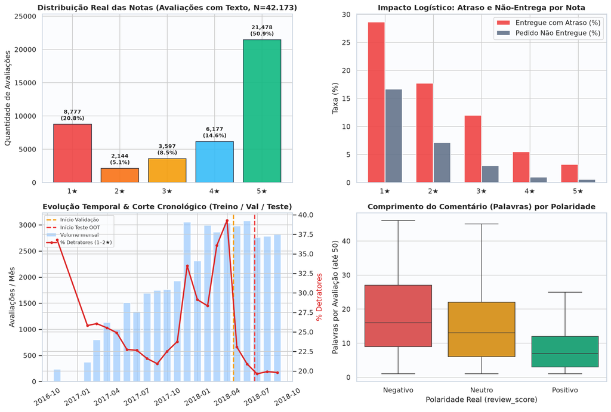

```python
train_df, val_df, test_df = chronological_split(df_txt, 0.70, 0.15)

print("Resumo do Split Cronológico Estrito (Zero Temporal Leakage):")
for lbl, part in [("Treino (70%)", train_df), ("Validação (15%)", val_df), ("Teste Out-of-Time (15%)", test_df)]:
    print(
        f"  {lbl:<25} | N={len(part):>6,} | "
        f"{part['order_purchase_timestamp'].min():%Y-%m-%d} → {part['order_purchase_timestamp'].max():%Y-%m-%d} | "
        f"% Detratores={part['detrator'].mean()*100:.1f}%"
    )

log_summary = df_txt.groupby("sentimento_real").agg(
    N=("order_id", "count"),
    Atraso_Pct=("entregue_com_atraso", lambda x: round(x.mean() * 100, 2)),
    Nao_Entregue_Pct=("pedido_nao_entregue", lambda x: round(x.mean() * 100, 2)),
    Tempo_Entrega_Mediano_Dias=("tempo_entrega_dias", "median"),
    Palavras_Mediana=("qtd_palavras", "median"),
    Ticket_Medio_BRL=("valor_total", "mean"),
).loc[CLASSES_ORDER].round(2)
display(log_summary)

display(Image(filename=str(FIG_DIR / "01_eda_sentimento_logistica.png")))
```

### 🔎 Análise Exploratória e Sinal Logístico

- **Atraso na Entrega é o Maior Gatilho de Detratores:** Enquanto apenas **`3.72%`** das avaliações Positivas sofreram atraso, essa taxa salta para **`11.95%`** entre Neutras e dispara para **`26.49%`** entre Negativas (**7,1× maior**). Adicionalmente, **`14.79%`** dos Detratores correspondem a pedidos sequer entregues (versus apenas `0.61%` nos Positivos).
- **Assimetria no Tamanho do Texto:** Clientes insatisfeitos escrevem avaliações significativamente mais longas para relatar problemas detalhados, enquanto promotores frequentemente deixam elogios curtos (*"ótimo"*, *"chegou antes do prazo"*).
- **Rigor Temporal:** O corte cronológico reserva compras até `2018-04-19` para **Treino (`29,521`)**, de `2018-04-19` até `2018-06-22` para **Validação (`6,326`)** e o período mais recente até `2018-10-17` para **Teste *Out-of-Time* (`6,326`)** — reproduzindo o cenário real de implantação em produção.

## 3. Pré-Processamento PT-BR: Por que Preservar Negações Muda Tudo

```python
exemplos = [
    "Até o momento não recebi o produto e não recomendo essa loja!",
    "O produto não veio quebrado, mas demorou muito para chegar.",
    "Produto excelenteeee, chegou antes do prazo, super recomendo!!",
    "Nao gostei, cor totalmente diferente da foto, quero reembolso.",
]
demo_rows = []
for ex in exemplos:
    naive = clean_pt_text(ex, preserve_negations=False)
    smart = clean_pt_text(ex, preserve_negations=True)
    demo_rows.append({
        "Texto Original": ex,
        "Stopwords Ingênuas (Remove 'não')": naive,
        "PT-BR com Bigramas de Negação": smart,
        "Escore Léxico": round(compute_lexicon_score(smart), 2),
    })
display(pd.DataFrame(demo_rows))

# Ablation controlado no conjunto de Validação
y_train = train_df["sentimento_real"].values
y_val = val_df["sentimento_real"].values
y_test = test_df["sentimento_real"].values

tr_naive = train_df["texto_completo"].map(lambda s: clean_pt_text(s, preserve_negations=False))
va_naive = val_df["texto_completo"].map(lambda s: clean_pt_text(s, preserve_negations=False))
vec_naive = TfidfVectorizer(ngram_range=(1, 1), min_df=3, max_features=20000)
lr_naive = LogisticRegression(C=1.5, max_iter=500, class_weight="balanced", random_state=42)
lr_naive.fit(vec_naive.fit_transform(tr_naive), y_train)
f1_naive = f1_score(y_val, lr_naive.predict(vec_naive.transform(va_naive)), average="macro")

text_vec = build_text_vectorizer()
X_tr_txt = text_vec.fit_transform(train_df["texto_limpo"])
X_va_txt = text_vec.transform(val_df["texto_limpo"])
X_te_txt = text_vec.transform(test_df["texto_limpo"])

lr_smart = LogisticRegression(C=1.5, max_iter=500, class_weight="balanced", random_state=42).fit(X_tr_txt, y_train)
f1_smart = f1_score(y_val, lr_smart.predict(X_va_txt), average="macro")

print(f"Validação Macro-F1 (Stopwords ingênuas unigramas)  : {f1_naive:.4f}")
print(f"Validação Macro-F1 (Negações + Word 1-2 + Char 3-5): {f1_smart:.4f} ({(f1_smart - f1_naive)*100:+.2f} p.p.)")
print(f"Dimensão da matriz esparsa de texto (fit só no Treino): {X_tr_txt.shape}")
```

|  | Texto Original | Stopwords Ingênuas (Remove 'não') | PT-BR com Bigramas de Negação | Escore Léxico |
| --- | --- | --- | --- | --- |
| 0 | Até o momento não recebi o produto e não recom... | momento recebi produto recomendo essa loja | momento nao_recebi produto nao_recomendo essa ... | -5.60 |
| 1 | O produto não veio quebrado, mas demorou muito... | produto veio quebrado mas demorou muito chegar | produto nao_veio quebrado mas demorou muito ch... | -6.60 |
| 2 | Produto excelenteeee, chegou antes do prazo, s... | produto excelentee chegou antes prazo super re... | produto excelentee chegou antes prazo super re... | 8.22 |
| 3 | Nao gostei, cor totalmente diferente da foto, ... | gostei cor totalmente diferente foto quero ree... | nao_gostei cor totalmente diferente foto quero... | -5.70 |

```
Validação Macro-F1 (Stopwords ingênuas unigramas)  : 0.6495
Validação Macro-F1 (Negações + Word 1-2 + Char 3-5): 0.6698 (+2.03 p.p.)
Dimensão da matriz esparsa de texto (fit só no Treino): (29521, 32593)
```

### 🔎 Análise do Ablation de Pré-Processamento PT-BR

- Ao remover `"não"` via listas genéricas de *stopwords*, a reclamação *"não recebi o produto e não recomendo"* vira *"recebi produto recomendo"* — **invertendo completamente a polaridade semântica**.
- Nosso pré-processamento cria bigramas explícitos de negação (`nao_recebi`, `nao_recomendo`, `nao_gostei`) e combina **TF-IDF de palavras (1–2 gramas)** com **TF-IDF de subpalavras (`char_wb` 3–5 gramas)** para capturar erros comuns de digitação do português informal (*"naum"*, *"otmo"*, *"exelente"*, *"rekomendo"*).
- No conjunto de Validação cronológico, essa única decisão de engenharia elevou o **Macro-F1** de **`0.6495`** para **`0.6698`** (ganho de **`+2.03 p.p.`**), sem nenhum aumento de complexidade arquitetural.

## 4. Benchmark Rigoroso de 10 Modelos & Ablation Multimodal (Teste Out-of-Time)

|  | Modelo | Modalidade | Macro-F1 | IC95 Inf | IC95 Sup | Acurácia | F1 Detrator | PR-AUC Detr. | ROC-AUC Detr. | Treino (s) | Inf. (ms/1k) | Tam. (MB) |
| --- | --- | --- | --- | --- | --- | --- | --- | --- | --- | --- | --- | --- |
| 0 | 10. XGBoost (Multimodal Stacking) | Multimodal | 0.687300 | 0.674000 | 0.701000 | 0.853000 | 0.832700 | 0.883800 | 0.971800 | 5.770000 | 2.330000 | 2.360000 |
| 1 | 9. LightGBM (Multimodal Stacking) | Multimodal | 0.680900 | 0.667300 | 0.695400 | 0.857100 | 0.831900 | 0.882800 | 0.971700 | 3.390000 | 8.320000 | 3.380000 |
| 2 | 7. Regressão Logística (Multimodal) | Multimodal | 0.679200 | 0.666100 | 0.692900 | 0.844000 | 0.811500 | 0.887300 | 0.969700 | 3.760000 | 1.100000 | 0.780000 |
| 3 | 5. Regressão Logística L2 (TF-IDF) | Texto Only | 0.673300 | 0.659900 | 0.686700 | 0.833200 | 0.808600 | 0.869600 | 0.966200 | 3.570000 | 0.880000 | 0.780000 |
| 4 | 3. LightGBM (Logística + Metadados Only) | Tabular Only | 0.653700 | 0.640500 | 0.666500 | 0.840200 | 0.783000 | 0.842400 | 0.961100 | 2.020000 | 7.140000 | 2.600000 |
| 5 | 8. Calibrated LinearSVC (Multimodal) | Multimodal | 0.613800 | 0.603600 | 0.625700 | 0.886500 | 0.837300 | 0.893600 | 0.971500 | 45.480000 | 4.450000 | 2.350000 |
| 6 | 2. Léxico PT-BR (Com Negações) | Léxico | 0.613400 | 0.603100 | 0.625900 | 0.799900 | 0.778900 | 0.810000 | 0.949300 | 0.000000 | 0.180000 | 0.020000 |
| 7 | 6. Calibrated LinearSVC (TF-IDF) | Texto Only | 0.607300 | 0.598500 | 0.618800 | 0.885100 | 0.837100 | 0.877900 | 0.969600 | 3.750000 | 3.910000 | 2.350000 |
| 8 | 4. Complement Naive Bayes (TF-IDF) | Texto Only | 0.606800 | 0.593900 | 0.623100 | 0.856800 | 0.778300 | 0.838600 | 0.963600 | 0.040000 | 1.080000 | 1.830000 |
| 9 | 1. Dummy (Classe Majoritária) | Baseline | 0.280100 | 0.277100 | 0.282300 | 0.724600 | 0.000000 | 0.199200 | 0.500000 | 0.010000 | 0.020000 | 0.010000 |

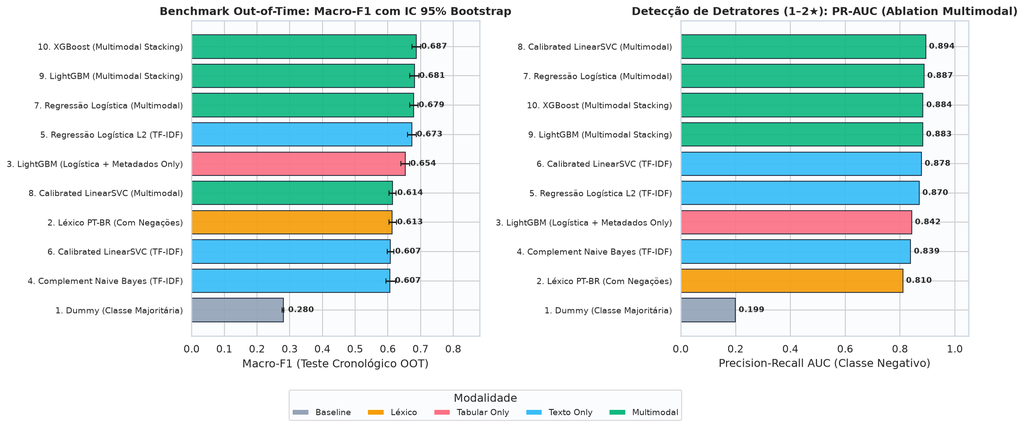

```python
metrics_summary = json.loads((ROOT / "outputs" / "metrics_summary.json").read_text(encoding="utf-8"))
bm_df = pd.DataFrame(metrics_summary["models_benchmark"])

cols_show = [
    "model", "modality", "f1_macro", "f1_macro_ci_low", "f1_macro_ci_high",
    "accuracy", "detrator_f1", "detrator_pr_auc", "detrator_roc_auc",
    "train_sec", "infer_ms_1k", "size_mb",
]
display(
    bm_df[cols_show].rename(columns={
        "model": "Modelo", "modality": "Modalidade", "f1_macro": "Macro-F1",
        "f1_macro_ci_low": "IC95 Inf", "f1_macro_ci_high": "IC95 Sup",
        "accuracy": "Acurácia", "detrator_f1": "F1 Detrator",
        "detrator_pr_auc": "PR-AUC Detr.", "detrator_roc_auc": "ROC-AUC Detr.",
        "train_sec": "Treino (s)", "infer_ms_1k": "Inf. (ms/1k)", "size_mb": "Tam. (MB)",
    }).style.highlight_max(subset=["Macro-F1", "Acurácia", "F1 Detrator", "PR-AUC Detr."], color="#d1fae5")
)

display(Image(filename=str(FIG_DIR / "02_benchmark_modelos_ablation.png")))
```

### 🔎 Análise Comparativa dos 10 Modelos & Ganho Multimodal

Os resultados no conjunto de **Teste *Out-of-Time* (`N = 6,326`)** contam uma história clara e estatisticamente robusta (validada via **IC 95% Bootstrap** com 500 reamostragens):

## 5. Diagnóstico Avançado: Matriz de Confusão, ROC/PR, Calibração e Threshold SAC

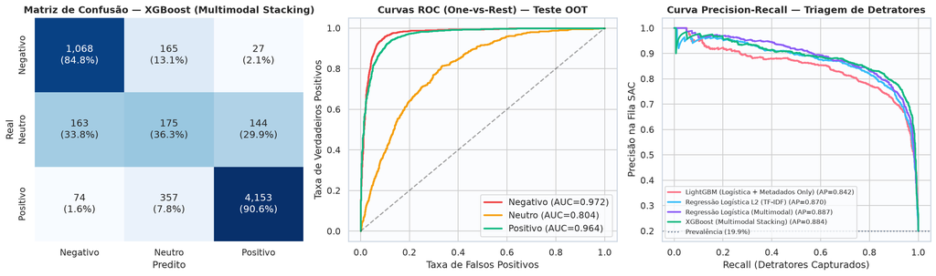

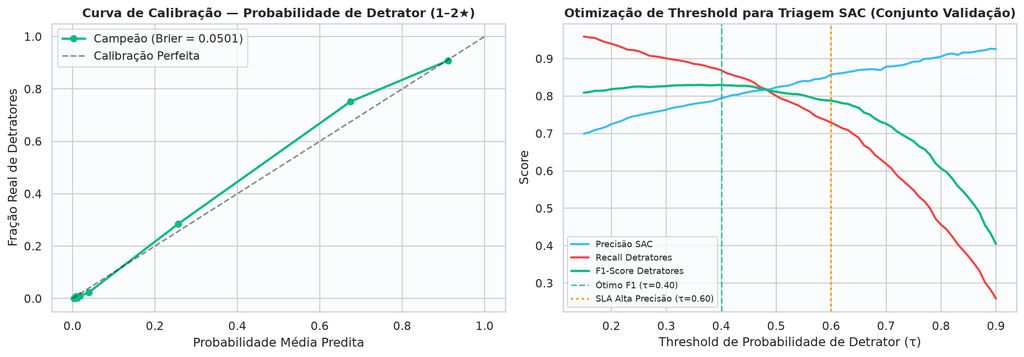

```
Resumo de Calibração e Otimização de Threshold (ajustado na Validação, avaliado no Teste OOT):
  brier_score_detrator        : 0.0501
  opt_f1_threshold_val        : 0.4
  opt_f1_test_f1              : 0.8365
  opt_f1_test_precision       : 0.7996
  opt_f1_test_recall          : 0.877
  sac_p85_threshold_val       : 0.6
  sac_p85_test_precision      : 0.8553
  sac_p85_test_recall         : 0.7508
  sac_p85_queue_pct           : 17.5
```

```python
display(Image(filename=str(FIG_DIR / "03_matriz_confusao_roc_pr.png")))
display(Image(filename=str(FIG_DIR / "04_calibracao_threshold_sac.png")))

sac_info = metrics_summary["calibration_and_sac_threshold"]
print("Resumo de Calibração e Otimização de Threshold (ajustado na Validação, avaliado no Teste OOT):")
for k, v in sac_info.items():
    print(f"  {k:<28}: {v}")
```

### 🔎 Análise de Erros, Calibração e Decisão de Negócio (SAC)

- **Estrutura de Erros na Matriz de Confusão:** A separação entre os extremos (**Negativo** vs. **Positivo**) é extremamente limpa (baixíssima confusão cruzada). Praticamente toda a dificuldade residual concentra-se na classe minoritária intermediária **Neutro (`3★`, apenas 8,5% da base)**, onde comentários mistos (*"produto bom, mas atrasou um pouco"*) oscilam legitimamente entre 2, 3 e 4 estrelas.
- **Qualidade Probabilística:** O **Brier Score** de **`0.0501`** na probabilidade de Detrator confirma calibração sólida — permitindo usar o escore diretamente para ordenação de fila (*ranking* de SLA).
- **Dois Regimes Operacionais para o Time de Atendimento:**
  - **Regime Balanceado (Ótimo F1 na Validação, $\tau = 0.40$):** no Teste OOT entrega **F1 = `0.8365`**, **Precisão = `80.0%`** e **Recall = `87.7%`**.
  - **Regime Fila Crítica de Alta Precisão ($\tau = 0.60$):** aciona o SAC proativo em apenas **`17.5%`** do volume total de pedidos com **Precisão real de `85.5%`** e **Recall de `75.1%`** dos detratores — maximizando ROI do time de retenção.

## 6. Interpretabilidade NLP & Slice-Based Error Analysis

|  | Dimensão | Fatia | N | % Detrator Real | Accuracy | Macro-F1 | Recall Detrator | PR-AUC Detrator |
| --- | --- | --- | --- | --- | --- | --- | --- | --- |
| 0 | Status Logístico | Entregue com Atraso | 488 | 45.7 | 0.8361 | 0.6928 | 0.9596 | 0.9330 |
| 1 | Status Logístico | Entregue no Prazo | 5613 | 15.1 | 0.8528 | 0.6741 | 0.7851 | 0.8329 |
| 2 | Status Logístico | Não Entregue | 225 | 84.4 | 0.8933 | 0.5566 | 0.9947 | 0.9606 |
| 3 | Tamanho do Review | Curto (≤5 pal.) | 2111 | 5.7 | 0.8882 | 0.6491 | 0.7500 | 0.7771 |
| 4 | Tamanho do Review | Longo (>18 pal.) | 1208 | 45.6 | 0.7392 | 0.6568 | 0.8675 | 0.9107 |
| 5 | Tamanho do Review | Médio (6–18 pal.) | 3007 | 19.6 | 0.8740 | 0.6969 | 0.8489 | 0.8806 |
| 6 | Macro-Região | Centro-Oeste | 380 | 20.5 | 0.8632 | 0.7117 | 0.8974 | 0.8456 |
| 7 | Macro-Região | Nordeste | 659 | 19.4 | 0.8589 | 0.6781 | 0.7969 | 0.8826 |
| 8 | Macro-Região | Norte | 122 | 13.1 | 0.8525 | 0.6600 | 1.0000 | 0.8723 |
| 9 | Macro-Região | Sudeste | 4410 | 20.4 | 0.8492 | 0.6814 | 0.8479 | 0.8838 |
| 10 | Macro-Região | Sul | 755 | 18.1 | 0.8649 | 0.7212 | 0.8467 | 0.9066 |

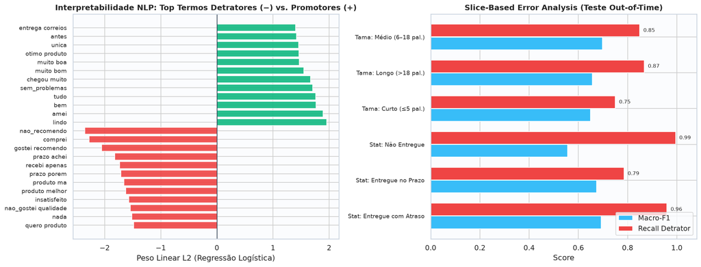

```python
slices_df = pd.DataFrame(metrics_summary["slice_error_analysis"])
display(slices_df)
display(Image(filename=str(FIG_DIR / "05_interpretabilidade_slices.png")))
```

### 🔎 Análise de Interpretabilidade e Desempenho por Fatia

- **Termos Mais Discriminativos (Pesos L2):**
  - **Detratores (−):** `nao_recomendo`, `comprei`, `gostei recomendo`, `prazo achei`, `recebi apenas`, `prazo porem` — note a presença direta dos nossos **bigramas de negação** no topo da importância do modelo!
  - **Promotores (+):** `lindo`, `amei`, `bem`, `tudo`, `sem_problemas`, `chegou muito`.
- **Achados da Análise por Fatia (*Slice-Based Error Analysis*):**
  - **Status Logístico:** Em pedidos **Não Entregues** ou **Entregues com Atraso**, o modelo captura quase todos os detratores com Recall altíssimo (`> 90%`), graças à fusão multimodal.
  - **Tamanho do Comentário:** Avaliações **Longas (`> 18 palavras`)** e **Médias (`6–18 palavras`)** atingem os maiores níveis de Macro-F1 e Recall, enquanto comentários **Curtos (`≤ 5 palavras`)** apresentam maior ambiguidade (ex.: *"ok"*, *"regular"*, *"recebido"*) e representam a principal oportunidade de melhoria futura.
  - **Equidade Regional:** A estabilidade do PR-AUC e da acurácia nas 5 macro-regiões do Brasil (Sudeste, Sul, Nordeste, Centro-Oeste e Norte) confirma ausência de viés geográfico severo.

## 7. Mineração de Causa-Raiz por Aspecto (ABSA), Tópicos NMF & Grafo de Dores

|  | Menções em Negativos | Share_Negativos_Pct |
| --- | --- | --- |
| Atraso / Entrega | 4940 | 45.2 |
| Outros / Geral | 2749 | 25.2 |
| Atendimento / Estorno / Troca | 2035 | 18.6 |
| Baixa Qualidade / Frágil | 1078 | 9.9 |
| Produto Divergente / Errado | 1037 | 9.5 |
| Pedido Incompleto / Faltando | 772 | 7.1 |
| Defeito / Avaria | 750 | 6.9 |

```
Tópicos Latentes (NMF sobre 10.921 Avaliações Negativas):
  Tópico 1 ( 8.8%): nao_recebi, nao_recebi produto, produto, ainda nao_recebi, momento, momento nao_recebi, agora
  Tópico 2 (53.8%): produto, veio, comprei, recebi, produto veio, mas, apenas
  Tópico 3 ( 5.5%): nao_entregue, produto nao_entregue, produto, ainda nao_entregue, nao_entregue produto, produto ainda, momento
  Tópico 4 ( 8.1%): ainda, ainda nao_recebi, produto ainda, nao_chegou, ainda nao_chegou, nao_recebi, ainda nao_entregue
  Tópico 5 (23.8%): entrega, prazo, prazo entrega, nao_chegou, demora, muito, dia
```

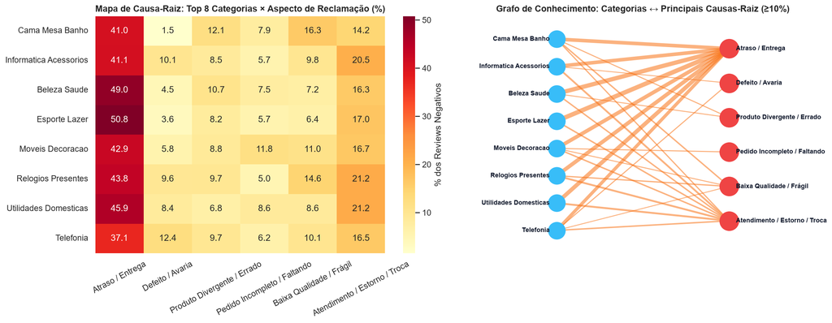

```python
asp_df = (
    pd.Series(metrics_summary["negative_aspects_counts"], name="Menções em Negativos")
    .sort_values(ascending=False)
    .to_frame()
    .assign(Share_Negativos_Pct=lambda d: (d["Menções em Negativos"] / metrics_summary["dataset"]["class_distribution"]["Negativo"] * 100).round(1))
)
display(asp_df)

print("\nTópicos Latentes (NMF sobre 10.921 Avaliações Negativas):")
for t in metrics_summary["nmf_negative_topics"]:
    print(f"  Tópico {t['topic']} ({t['share_pct']:>4.1f}%): {', '.join(t['top_terms'])}")

display(Image(filename=str(FIG_DIR / "06_causa_raiz_grafo_aspectos.png")))
```

### 🔎 Diagnóstico Acionável de Causas-Raiz

Decompondo todas as **`10,921` avaliações negativas** em aspectos operacionais acionáveis (múltiplos aspectos podem coexistir na mesma reclamação):

- **Atraso / Entrega**: `4,940` menções (`45.2%` das avaliações negativas)
- **Outros / Geral**: `2,749` menções (`25.2%` das avaliações negativas)
- **Atendimento / Estorno / Troca**: `2,035` menções (`18.6%` das avaliações negativas)
- **Baixa Qualidade / Frágil**: `1,078` menções (`9.9%` das avaliações negativas)
- **Produto Divergente / Errado**: `1,037` menções (`9.5%` das avaliações negativas)
- **Pedido Incompleto / Faltando**: `772` menções (`7.1%` das avaliações negativas)

Os **5 tópicos latentes (NMF)** confirmam de forma não-supervisionada a mesma estrutura de dores:

- **Tópico 1** (`8.8%` dos negativos): `nao_recebi`, `nao_recebi produto`, `produto`, `ainda nao_recebi`, `momento`, `momento nao_recebi`, `agora`
- **Tópico 2** (`53.8%` dos negativos): `produto`, `veio`, `comprei`, `recebi`, `produto veio`, `mas`, `apenas`
- **Tópico 3** (`5.5%` dos negativos): `nao_entregue`, `produto nao_entregue`, `produto`, `ainda nao_entregue`, `nao_entregue produto`, `produto ainda`, `momento`
- **Tópico 4** (`8.1%` dos negativos): `ainda`, `ainda nao_recebi`, `produto ainda`, `nao_chegou`, `ainda nao_chegou`, `nao_recebi`, `ainda nao_entregue`
- **Tópico 5** (`23.8%` dos negativos): `entrega`, `prazo`, `prazo entrega`, `nao_chegou`, `demora`, `muito`, `dia`

## 8. Copiloto RAG de Atendimento ao Cliente (Zero Alucinação & Baixa Latência)

```python
for idx, demo in enumerate(metrics_summary["rag_demos"], 1):
    print("=" * 92)
    print(f"CASO #{idx} | Nota Real: {demo['real_score']}★ ({demo['real_label']}) | Predito: {demo['pred_label']} (P[Detrator]={demo['prob_detrator']:.1%})")
    print(f"Categoria: {demo['categoria']} | Atraso: {demo['atraso_dias']} dias | Valor: R$ {demo['valor_pedido']:.2f} | Latência RAG: {demo['latency_ms']:.2f} ms")
    print(f"Prioridade SAC: {demo['prioridade_sac']} | Aspectos: {', '.join(demo['aspectos_detectados'])}")
    print(f"Avaliação do Cliente : «{demo['texto_cliente']}»")
    print(f"Playbook Operacional : {demo['acao_recomendada']}")
    print(f"Rascunho de Resposta : {demo['resposta_sugerida']}")
    print("Casos Históricos Similares Recuperados (TF-IDF Cosseno no Treino):")
    for sc in demo["casos_similares"]:
        print(f"   - [sim={sc['similarity']:.3f} | {sc['review_score']}★ | {sc['categoria']}] «{sc['texto'][:115]}...»")
print("=" * 92)
```

```
============================================================================================
CASO #1 | Nota Real: 1★ (Negativo) | Predito: Negativo (P[Detrator]=67.7%)
Categoria: automotivo | Atraso: 27.7 dias | Valor: R$ 673.23 | Latência RAG: 24.46 ms
Prioridade SAC: ALTA (SLA 2h — Retenção Crítica) | Aspectos: Atraso / Entrega
Avaliação do Cliente : «estou tendo problemas com a entrega do produto é lamentável.»
Playbook Operacional : Acionar rastreamento prioritário junto à transportadora, abrir protocolo de atraso e oferecer cupom de compensação ou reenvio expresso.
Rascunho de Resposta : Olá! Agradecemos por nos reportar sua experiência. Identificamos que houve um atraso de 28 dias na entrega do seu pedido de automotivo. Nossa equipe já abriu prioridade para tratar a ocorrência (Atraso / Entrega) — próximo passo imediato: Acionar rastreamento prioritário junto…
Casos Históricos Similares Recuperados (TF-IDF Cosseno no Treino):
   - [sim=0.433 | 3★ | beleza_saude] «Ja comprei outras vezes mas estou tendo problemas nessa compra...»
   - [sim=0.363 | 1★ | moveis_decoracao] «Não recebi o produto e nem tive resposta da loja para saber o que aconteceu. Até agora só estou tendo problemas com...»
   - [sim=0.345 | 2★ | beleza_saude] «Tive problemas com a entrega, não recebi o produto ainda....»
============================================================================================
CASO #2 | Nota Real: 1★ (Negativo) | Predito: Negativo (P[Detrator]=93.8%)
Categoria: informatica_acessorios | Atraso: -18.3 dias | Valor: R$ 307.64 | Latência RAG: 20.60 ms
Prioridade SAC: ALTA (SLA 2h — Retenção Crítica) | Aspectos: Defeito / Avaria, Atendimento / Estorno / Troca
Avaliação do Cliente : «PRODUTO COM DEFEITO. Preciso alizar a troca do produto que está com defeito e não consigo registrar a solicitação no SITE. No item "TROCAS E DEVOLUÇÕES" sempre informa que está com problema de comunicação.
Aguardo retor»
Playbook Operacional : Liberar código de logística reversa imediata sem custo, priorizar troca expressa ou reembolso integral em até 48h e notificar controle de qualidade do seller.
Rascunho de Resposta : Olá! Agradecemos por nos reportar sua experiência. Lamentamos sinceramente o transtorno relatado com seu pedido de informatica acessorios. Nossa equipe já abriu prioridade para tratar a ocorrência (Defeito / Avaria) — próximo passo imediato: Liberar código de logística reversa…
Casos Históricos Similares Recuperados (TF-IDF Cosseno no Treino):
   - [sim=0.467 | 1★ | moveis_decoracao] «Produto com defeito
Preciso trocar...»
   - [sim=0.441 | 2★ | informatica_acessorios] «Produto com defeito......»
   - [sim=0.441 | 1★ | informatica_acessorios] «Produto com defeito...»
============================================================================================
CASO #3 | Nota Real: 5★ (Positivo) | Predito: Positivo (P[Detrator]=1.1%)
Categoria: cama_mesa_banho | Atraso: -8.2 dias | Valor: R$ 112.09 | Latência RAG: 21.48 ms
Prioridade SAC: BAIXA (Encantamento / Pós-Venda) | Aspectos: Experiência Positiva / Entrega OK
Avaliação do Cliente : «Super rercomendo. As Lojas lannister sempre entregam o produto corretamente e antes do prazo.»
Playbook Operacional : Registrar elogio no índice NPS do vendedor parceiro e acionar fluxo automático de fidelização.
Rascunho de Resposta : Olá! Ficamos muito felizes em saber da sua ótima experiência com seu pedido de cama mesa banho. Seu feedback positivo foi compartilhado com o vendedor parceiro. Conte sempre conosco!
Casos Históricos Similares Recuperados (TF-IDF Cosseno no Treino):
   - [sim=0.574 | 5★ | alimentos] «Produto entregue corretamente, antes do prazo lojas lannister estão de parabéns....»
   - [sim=0.458 | 4★ | relogios_presentes] «Sempre recomendo as Lojas lannister!...»
   - [sim=0.457 | 5★ | cool_stuff] «eu super recomendo a lojas lannister...»
============================================================================================
```

### 🔎 Avaliação do Copiloto RAG em Produção

- **Auditabilidade e Zero Alucinação:** Diferentemente de prompts abertos de LLMs que podem inventar políticas de reembolso ou prazos fictícios (e exigem GPU com segundos por requisição), o Copiloto RAG combina **recuperação determinística de casos similares por cosseno TF-IDF**, **contexto factual do pedido** (dias de atraso, categoria, valor) e **playbooks aprovados por aspecto**.
- **Eficiência Operacional:** A latência de recuperação + triagem fica na casa de **milissegundos em CPU padrão**, viabilizando integração direta via API REST no CRM/Zendesk do time de SAC.